# Statistical Hypothesis Testing

Final Project

Mateusz Mglej

2025-01-30

```r
library(nleqslv) # Package for solving nonlinear equations
library(ggplot2)
```

## Theoretical Solution

### Theorem

Let $\Theta \subset \mathbb{R}$ and suppose $P_\theta$ has a density $f_\theta$ with respect to some fixed measure $\mu$, belonging to a one-dimensional exponential family of the form:

$$f_\theta(x) = h(x)\exp\{C(\theta)T(x) - B(\theta)\}$$

Define the sufficient statistic for $\theta$ as:
$$S(\mathbf{X}) = \sum_{i=1}^n T(X_i)$$

Then:

- For testing $H_0: \theta \in [\theta_a, \theta_b]$ versus $H_1: \theta \notin [\theta_a, \theta_b]$, the test has the form:
  $$\varphi(\mathbf{X}) =
  \begin{cases}
  1, & \text{if } S(\mathbf{X}) \notin [c_a, c_b] \\
  0, & \text{if } S(\mathbf{X}) \in [c_a, c_b]
  \end{cases}$$
  where constants $c_a, c_b$ are chosen so that:
  $$\mathbb{E}_{\theta_a}[\varphi(\mathbf{X})] =
  \mathbb{E}_{\theta_b}[\varphi(\mathbf{X})] = \alpha$$
  This is the uniformly most powerful unbiased test.
- For testing $H_0: \theta = \theta_0$ versus $H_1: \theta \neq \theta_0$, the test has the same form:
  $$\varphi(\mathbf{X}) =
  \begin{cases}
  1, & \text{if } S(\mathbf{X}) \notin [c_a, c_b] \\
  0, & \text{if } S(\mathbf{X}) \in [c_a, c_b]
  \end{cases}$$
  with constants $c_a, c_b$ chosen so that:
  $$\mathbb{E}_{\theta_0}[\varphi(\mathbf{X})] = \alpha, \quad
  \mathbb{E}_{\theta_0}[\varphi(\mathbf{X}) S(\mathbf{X})] = \alpha \cdot
  \mathbb{E}_{\theta_0}[S(\mathbf{X})]$$

This test is also uniformly most powerful among all unbiased tests.

### Our Test

In our case, the exponential distribution belongs to the exponential family. The sufficient statistic is:  
$T(X) = \sum_{i=1}^{n}X_i$

We will test the hypothesis $H_0: \lambda = 4$ vs. $H_1: \lambda \neq 4$

For simplicity, let $k = 1/\lambda$.  
Then we have: $X_1, ..., X_n$ i.i.d. from $\text{Exp}(k)$, and the expected value is $1/k = \lambda$.

The test has the form:
$$\varphi(\mathbf{X}) =
\begin{cases}
1, & \text{if } T(\mathbf{X}) \notin [a, b] \\
0, & \text{if } T(\mathbf{X}) \in [a, b]
\end{cases}$$
where constants $a, b$ are chosen such that:
$$\mathbb{E}_{\theta_0}[\varphi(\mathbf{X})] = \alpha, \quad
\mathbb{E}_{\theta_0}[\varphi(\mathbf{X}) T(\mathbf{X})] = \alpha \cdot
\mathbb{E}_{\theta_0}[T(\mathbf{X})]$$

### Distribution of the Test Statistic under the Null Hypothesis

$X_1, ..., X_n$ is a random sample from $\text{Exp}(k)$.  
Therefore, $T(X) = \sum_{i=1}^{n}X_i \sim \text{Gamma}(n, k)$

### Finding the Constants $a, b$, with $a < b$

#### First Condition

$$\mathbb{E}_{\theta_0}[\varphi(\mathbf{X})] = \alpha$$

$$1 \cdot P_{\theta_0}(T(X) \notin (a,b)) = \alpha$$

$$P_{\theta_0}(T(X) \in (a,b)) = 1 - \alpha$$

$$P_{\theta_0}(a < T(X) < b) = 1 - \alpha$$

Under the null, $T(X) \sim \text{Gamma}(n, k)$, so:

$$F_{\text{Gamma}(n, k)}(b) - F_{\text{Gamma}(n, k)}(a) = 1 - \alpha$$

#### Second Condition

$$\mathbb{E}_{\theta_0}[\varphi(\mathbf{X}) T(\mathbf{X})] = \alpha \cdot
\mathbb{E}_{\theta_0}[T(\mathbf{X})]$$

Assume $Y \sim \text{Gamma}(n, k)$. Then:

$$f_Y(t) = \frac{k^n}{\Gamma(n)} t^{n-1} e^{-kt} \cdot \mathbb{1}_{(0,
\infty)}(t)$$

$$\mathbb{E}[Y] = \frac{n}{k}$$

Right-hand side:

$$\alpha \cdot \mathbb{E}_{\theta_0}[T(\mathbf{X})] = \alpha \cdot
\frac{n}{k}$$

Substitute into the second expectation:

$$\mathbb{E}_{\theta_0}[\varphi(\mathbf{X}) T(\mathbf{X})] = \alpha \cdot
\frac{n}{k}$$

Written as an integral (omitting steps similar to the first condition):

$$\int_{a}^{b} t \cdot t^{n-1} e^{-kt} \, dt = (1 - \alpha) \cdot
\frac{n}{k} \cdot \frac{\Gamma(n)}{k^n}$$

$$\int_{a}^{b} t^n e^{-kt} \, dt = (1 - \alpha) \cdot
\frac{\Gamma(n+1)}{k^{n+1}}$$

$$\int_{a}^{b} \frac{k^{n+1}}{\Gamma(n+1)} t^n e^{-kt} \, dt = 1 - \alpha$$

$$F_{\text{Gamma}(n+1, k)}(b) - F_{\text{Gamma}(n+1, k)}(a) = 1 - \alpha$$

### Final System of Equations

We solve the following system numerically to find the constants $a, b$:

$$\begin{cases}
F_{\text{Gamma}(n, k)}(b) - F_{\text{Gamma}(n, k)}(a) = 1 - \alpha \\
F_{\text{Gamma}(n+1, k)}(b) - F_{\text{Gamma}(n+1, k)}(a) = 1 - \alpha
\end{cases}$$

## One-Sample Test

### Parameters

```r
alpha <- 0.05
n <- 20

# Null hypothesis parameter
lambda <- 4
k <- 1 / lambda

# Parameter for the generated sample
lambda2 <- 2
k2 <- 1 / lambda2
```

Checking the distribution generators in R

```r
# Should be close to 1/5 = 0.2
mean(rexp(1000, 5))
```

```
## [1] 0.2123532
```

```r
# Should be close to 20/5 = 4
mean(rgamma(1000, 20, 5))
```

```
## [1] 3.992103
```

Generating a sample and computing the test statistic

```r
X <- rexp(n, k2)
T <- sum(X)
T
```

```
## [1] 35.21126
```

Finding the constants $a,b$

```r
uklad <- function(rownania){
  a <- rownania[1]
  b <- rownania[2]

  eq1 <- pgamma(b, n+1, k) - pgamma(a, n+1, k) - (1 - alpha)
  eq2 <- pgamma(b, n, k) - pgamma(a, n, k) - (1 - alpha)

  c(eq1, eq2)
}

# Initial guess near the mean
m <- n / k

solution <- nleqslv(c(m - 10, m + 10), uklad)
solution$x
```

```
## [1]  49.75731 120.54966
```

```r
a <- solution$x[1]
b <- solution$x[2]
```

```r
T
```

```
## [1] 35.21126
```

```r
T < a | T > b
```

```
## [1] TRUE
```

## Empirical Power for Given Parameters

Simulation Setup

```r
MC = 1000000

alpha <- 0.05
lamdba <- 4
k <- 1 / lamdba
n <- 20

# Lambda values for the power curve
lamdamoc <- seq(2, 6, by = 0.05)
```

Finding constants $a,b$ again

```r
uklad <- function(rownania){
  a <- rownania[1]
  b <- rownania[2]

  eq1 <- pgamma(b, n+1, k) - pgamma(a, n+1, k) - (1 - alpha)
  eq2 <- pgamma(b, n, k) - pgamma(a, n, k) - (1 - alpha)

  c(eq1, eq2)
}

m <- n / k

solution <- nleqslv(c(m - 10, m + 10), uklad)
solution$x
```

```
## [1]  49.75731 120.54966
```

```r
a <- solution$x[1]
b <- solution$x[2]
```

Running the Monte Carlo Simulation for each $\lambda$

```r
empmoc <- c()

for(i in 1:length(lamdamoc)){
  TMC <- c()
  for(j in 1:MC){
    X <- rexp(n, 1 / lamdamoc[i])
    TMC[j] <- sum(X)
  }
  empmoc[i] <- sum(TMC < a | TMC > b) / MC
}
```

Plotting the Empirical Power as a Function of $\lambda$

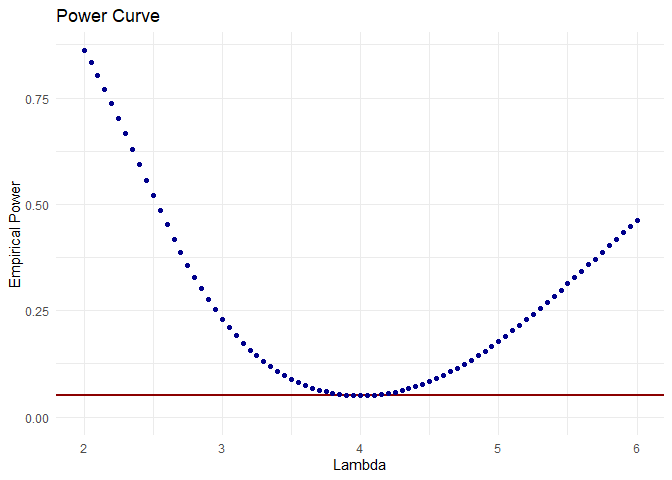

```r
df <- data.frame(lamdamoc, empmoc)

ggplot(df, aes(x = lamdamoc, y = empmoc)) +
  geom_hline(yintercept = 0.05, color = "darkred", linewidth = 1) +
  geom_point(color = "darkblue") +
  theme_minimal() +
  labs(x = "Lambda", y = "Empirical Power", title = "Power Curve") +
  scale_y_continuous(limits = c(0, max(df$empmoc, na.rm = TRUE)))
```